# The *decorr* package. Graph Analysis of Prehistorical Iconography with R

Thomas Huet, Jose Pozo, Craig Alexander

2020-12-05

The R package `decorr` is grounded on graph theory and spatial analysis. It offers concepts and functions to model Prehistorical iconographical composition and to prepare further analysis (clustering, Harris diagram, etc.) in order to contribute to cross-cultural iconography comparisons studies by a higher normalization of quantitative analysis (Alexander 2008; Huet and Alexander 2015; Huet 2018).

# Decoration graphs

The main principle of `decorr` package is to considerate any iconographic compositions (here, ‘decorations’) as relative neighborhood graphs (RNG) of graphical units (GUs): a decoration graph. The GUs are decorated surfaces (`POLYGONS`) modelised as nodes (`POINTS`) sharing a proximity link one with another (edges) when their Voronoi cell share a border.

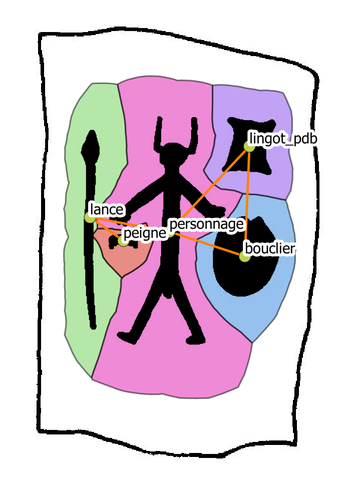

GIS view of the Cerro Muriano 1 stelae with the Voronoi cells of its GUs, GUs (nodes) and proximity links between these GUs (edges)

RNG is “*a powerful model of low-level visual process*” (Toussaint 1980). Graph theory offers a conceptual framework and indices (global at the entire graph scale, local at the vertex scale) to deal with notions of networks, relationships and neighbourhoods. The graph is commonly built within a GIS interface. Indeed, use of GIS allows to consitute a spatial database of the decoration’s iconographic contents and facilitates data recording and visualization: snapping options for example to connect GUs (nodes) with lines (edges), features symbology, layer transparency, etc.

The R package `decorr` is composed by functions and a dataset example. The main packages used by the `decorr` package are:

- [magick-image package](https://cran.r-project.org/web/packages/magick/vignettes/intro.html): for drawing/images management
- [igraph package](https://igraph.org/r/): for graphs management
- [rgdal](https://cran.r-project.org/web/packages/rgdal/index.html): for shapefiles management

# Functions

Decoration graphs are constructed from nodes and the edges. As a RNG graph, graphs are 1-component: each decoration graph covers all the GUs of the decoration. The functions of the `decorr` package provide basic requirements to manage these nodes data (`.csv`, `.tsv` or `.shp`) and edges data (`.csv`, `.tsv` or `.shp`) to create graphs, to plot and to compare them, to select contemporaneous GUs compositions.

```r
library(decorr)
cat(ls("package:decorr"), sep="\n")
> contemp_nds
> disambiguate_duplicates
> eds_compar
> grDeviceOpen
> labels_shadow
> list_compar
> list_dec
> named_edges
> named_nodes
> nds_compar
> plot_compar
> plot_dec_grph
> read_eds
> read_nds
> same_elements
> side_plot
```

## Plot

The graphical functions, `plot_dec_grph()` and `plot_compar()` allow different choices for the color and the size of the nodes, edges or labels. For example, nodes and edges of `Cerro Muriano 1`, and the field `type` used for the label can be selected instead of the default `id` field (identifier of the node)

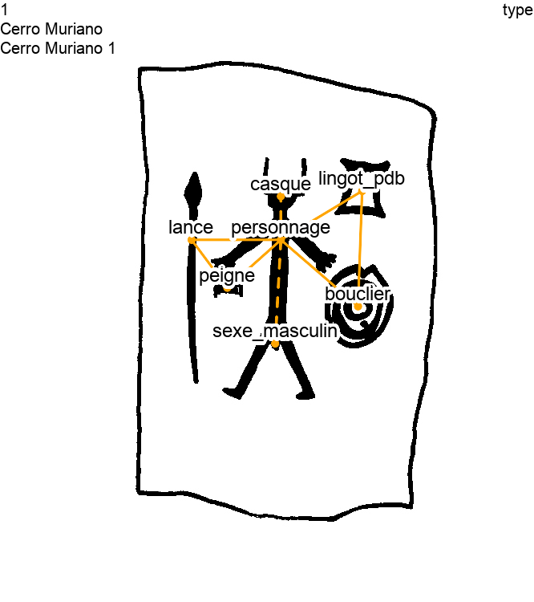

Cerro Muriano 1 drawing with the type of each GU

```r
nds.df <- read_nds(site = "Cerro Muriano", decor = "Cerro Muriano 1", doss = dataDir)
eds.df <- read_eds(site = "Cerro Muriano", decor = "Cerro Muriano 1", doss = dataDir)
img.graph <- plot_dec_grph(nodes = nds.df,
                           edges = eds.df,
                           site = "Cerro Muriano",
                           decor = "Cerro Muriano 1",
                           nds.var = 'type',
                           lbl.size=2,
                           doss = dataDir)
magick::image_read(img.graph)
```

A new field, `long_cm` is added to Cerro Muriano 1 nodes and the graph is replot on this field instead of the `type` field, with brown colors and label bigger sizes

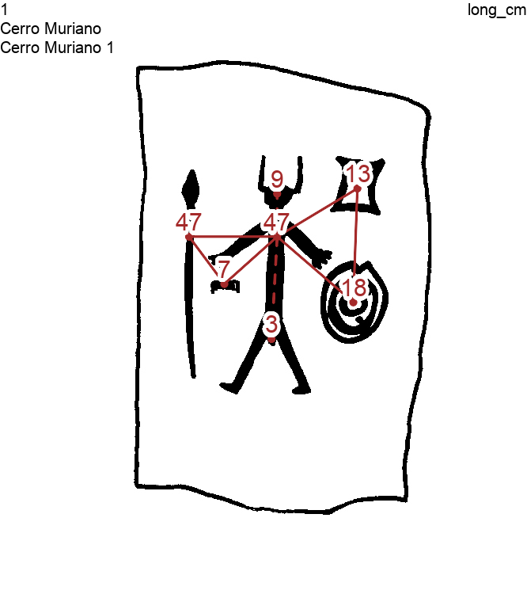

Cerro Muriano 1 drawing with the maximum length (in cm) of each GU

```r
nds.df <- read_nds(site = "Cerro Muriano", decor = "Cerro Muriano 1", doss = dataDir)
nds.df$long_cm <- c(47, 9, 47, 18, 7, 3, 13)
eds.df <- read_eds(site = "Cerro Muriano", decor = "Cerro Muriano 1", doss = dataDir)
img.graph <- plot_dec_grph(nodes = nds.df,
                           edges = eds.df,
                           site = "Cerro Muriano",
                           decor = "Cerro Muriano 1",
                           nds.var = 'long_cm',
                           nd.color = "brown",
                           lbl.color = "brown",
                           eds.color = "brown",
                           lbl.size=2.5,
                           doss = dataDir)
magick::image_read(img.graph)
```

## Compare

Between all the graphs, or between a pair of graphs, elements of the graphs (nodes and edges) can be compared with the `same_elements()` and `plot_compar()` functions

- `same_elements()` function permits to count each common elements between *n* graphs
- `plot_compar()` function shows a graphical output for these coomon elements

By default, between a pairwise of decorations, common nodes and edges are displayed in red, but their colors – and other graphical parameters – can be modified. When not all GUs are contemporaneous one with another, the non-contemporaneous ones can be removed with the `contemp_nds()` function.

### Nodes comparisons

A classic study in archaeological research is to count the common nodes between decoration pairwises. This can be done with the `same_elements()` function with a node focus (`focus = "nodes"`), and considering for example their `type`.

```r
imgs_path <- paste0(dataDir, "/imgs.tsv")
nodes_path <- paste0(dataDir, "/nodes.tsv")
edges_path <- paste0(dataDir, "/edges.tsv")
imgs <- read.table(imgs_path, sep="\t", stringsAsFactors = FALSE)
nodes <- read.table(nodes_path, sep="\t", stringsAsFactors = FALSE)
edges <- read.table(edges_path, sep="\t", stringsAsFactors = FALSE)
lgrph <- list_dec(imgs, nodes, edges)
df.same_nodes <- same_elements(lgrph,
                               focus = "nodes",
                               nds.var = "type")
knitr::kable(df.same_nodes, row.names = TRUE) %>%
  kable_styling(full_width = FALSE, position = "center", font_size=12)
```

|  | 1 | 2 | 3 | 4 | 5 |
| --- | --- | --- | --- | --- | --- |
| 1 | 7 | 2 | 3 | 4 | 2 |
| 2 | 2 | 12 | 5 | 9 | 3 |
| 3 | 3 | 5 | 6 | 4 | 3 |
| 4 | 4 | 9 | 4 | 12 | 3 |
| 5 | 2 | 3 | 3 | 3 | 4 |

The results of `same_elements()` is a symetrical dataframe where row names and column headers are the identifiers of the decorations:

- cells of the dataframe show the total number of common nodes by decoration pairwises
- the diagonal of the dataframe shows the total number of nodes or edges of a given decoration

For example, the decoration `4` has twelve (12) nodes, shares nine (9) nodes having the same `type` (common nodes) with the decoration `2` and shares four (4) nodes having the same `type` with the decoration `3`. To compare decorations `2`, `3` and `4` on the `type` variable:

- first: `type` variable is pasted to the `list_compar()` function
- then: the plot is made with the `plot_compar()` function

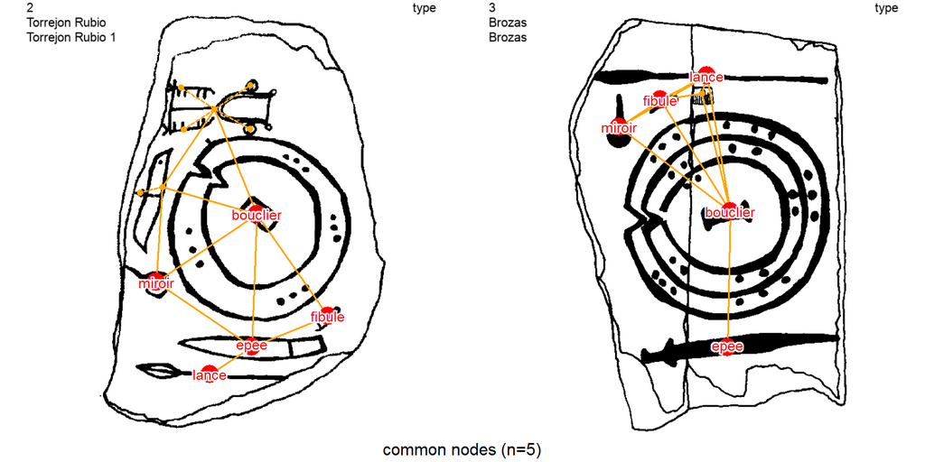

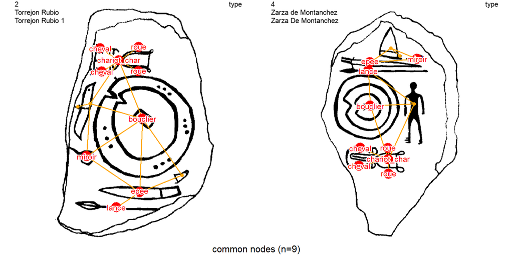

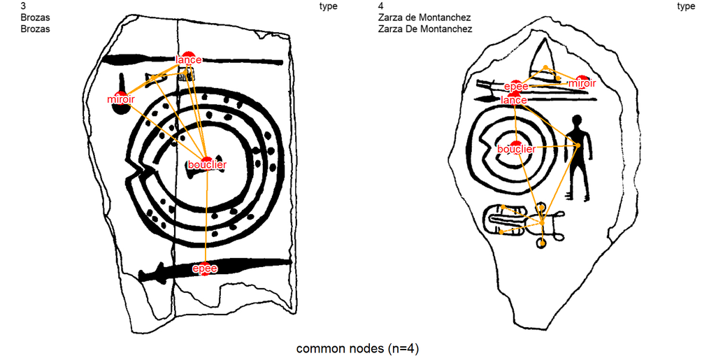

```r
dec.to.compare <- c(2, 3, 4)
imgs_path <- paste0(dataDir, "/imgs.tsv")
nodes_path <- paste0(dataDir, "/nodes.tsv")
edges_path <- paste0(dataDir, "/edges.tsv")
imgs <- read.table(imgs_path, sep="\t", stringsAsFactors = FALSE)
nodes <- read.table(nodes_path, sep="\t", stringsAsFactors = FALSE)
edges <- read.table(edges_path, sep="\t", stringsAsFactors = FALSE)
lgrph <- list_dec(imgs, nodes, edges)
g.compar <- list_compar(lgrph, nds.var = "type")
nds_compar <- plot_compar(listg = g.compar,
                          graph2 = dec.to.compare,
                          focus = "nodes",
                          nds.size = c(0.5, 1.5),
                          doss = dataDir)
knitr::include_graphics(nds_compar)
```

The function creates an image for each pairwise of stelae contained in the `dec.to.compare` variable (2, 3, 4), with a focus on nodes (`focus = "nodes"`). That is to say $\frac{n!}{(n-2)!2!}$ pairwise comparisons, when `n` is the number of compared decoration.

### Edges comparisons

A not so classic study in archaeological research is to count the common edges between decorations pairwise. The `same_elements()` function with an edge focus (`focus = "edges"`) and considering the `type` of the nodes

```r
imgs_path <- paste0(dataDir, "/imgs.tsv")
nodes_path <- paste0(dataDir, "/nodes.tsv")
edges_path <- paste0(dataDir, "/edges.tsv")
imgs <- read.table(imgs_path, sep="\t", stringsAsFactors = FALSE)
nodes <- read.table(nodes_path, sep="\t", stringsAsFactors = FALSE)
edges <- read.table(edges_path, sep="\t", stringsAsFactors = FALSE)
lgrph <- list_dec(imgs, nodes, edges)
df.same_edges <- same_elements(lgrph, nds.var = "type", focus = "edges")
knitr::kable(df.same_edges,row.names = T) %>%
  kable_styling(full_width = FALSE, position = "center", font_size=12)
```

|  | 1 | 2 | 3 | 4 | 5 |
| --- | --- | --- | --- | --- | --- |
| 1 | 8 | 0 | 1 | 2 | 0 |
| 2 | 0 | 15 | 3 | 7 | 1 |
| 3 | 1 | 3 | 10 | 1 | 2 |
| 4 | 2 | 7 | 1 | 14 | 1 |
| 5 | 0 | 1 | 2 | 1 | 4 |

In this dataframe:

- cells show the total number of common edges by decorations
- the diagonal of the dataframe shows is the total number of a given decoration

Here, the decoration `2` has fiftheen (15) edges, and share three (3) common edges with the decoration `3`. To show them, and the decoration `4`, we use the `list_compar()` function on the same variable (`type`) and the `plot_compar()` function with an edge focus (`focus = "edges"`).

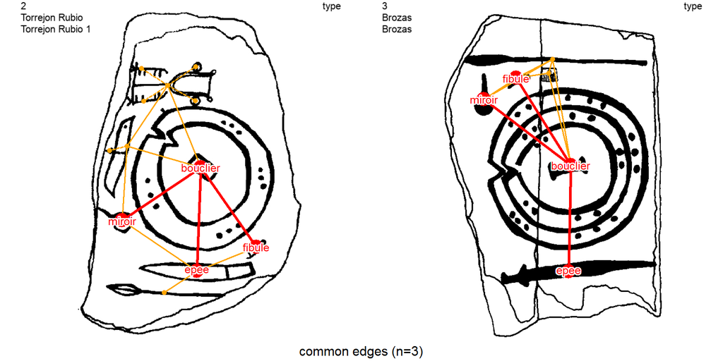

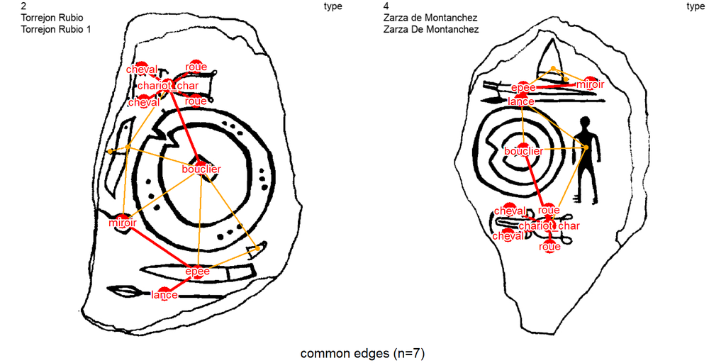

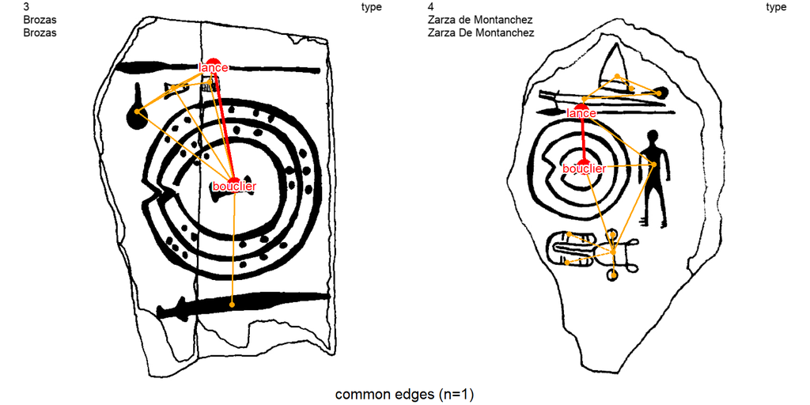

```r
dec.to.compare <- c(2, 3, 4)
imgs_path <- paste0(dataDir, "/imgs.tsv")
nodes_path <- paste0(dataDir, "/nodes.tsv")
edges_path <- paste0(dataDir, "/edges.tsv")
imgs <- read.table(imgs_path, sep="\t", stringsAsFactors = FALSE)
nodes <- read.table(nodes_path, sep="\t", stringsAsFactors = FALSE)
edges <- read.table(edges_path, sep="\t", stringsAsFactors = FALSE)
lgrph <- list_dec(imgs, nodes, edges) # call function
g.compar <- list_compar(lgrph, nds.var = "type")
eds_compar <- plot_compar(listg = g.compar,
                          graph2 = dec.to.compare,
                          focus = "edges",
                          nds.size = c(0.5, 1.5),
                          doss = dataDir)
# open image
knitr::include_graphics(eds_compar)
```

## Manage contemporaneous contents

It occurs that some GUs are non-contemporaneous one with the others, like for the Ibahernando stelae. This stelae have been found reused as a funerary steale during Roman times (Bash 1966). A latin inscription (ecriture, node 1) have been carved over a spear (lance, node 2) and overlaps partially a V-notched shield (bouclier, node 3). The edges between node 1 and node 2, and the edge between node 1 and node 3, are *overlap* edges.

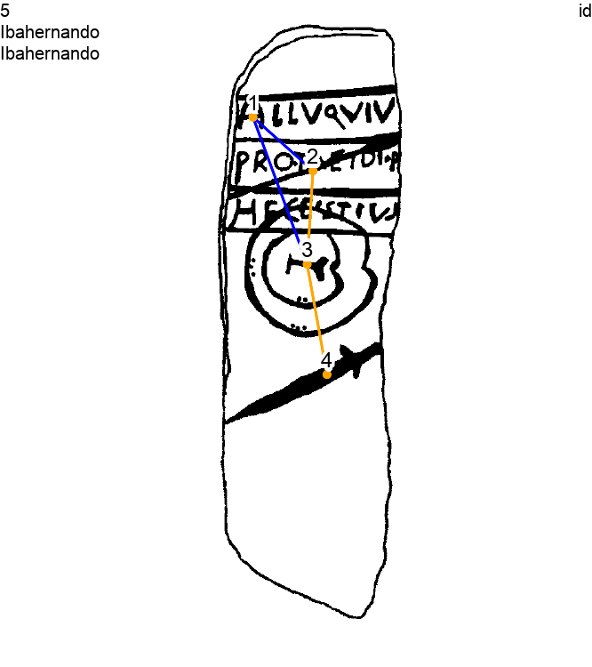

```r
nds.df <- read_nds(site = "Ibahernando",
                   decor = "Ibahernando",
                   doss = dataDir)
eds.df <- read_eds(site = "Ibahernando",
                   decor = "Ibahernando",
                   doss = dataDir)
img.graph <- plot_dec_grph(nodes = nds.df,
                           edges = eds.df,
                           site = "Ibahernando",
                           decor = "Ibahernando",
                           lbl.size = 2,
                           doss = dataDir)
magick::image_read(img.graph)
```

In this case, the non-contemporaneous layers of decoration should be removed before the comparison process. To do so, the original graph (1-component) will be splitted into different sub-graphs (n-component) by selecting `>` edges (see *overlap* edges). The studied graph component will be retrieved with the component membership of a selected node in the `contemp_nds()` function parameters.

To study only the Late Bronze Age iconographic layer of the Ibahernando steale, we can choose the Late Bronze Age node 4, the figure of sword (epee) dated to the middle and final stages of Late Bronze Age (ca 1250-950 BC). This node is supposed to be contemporaneous to node 2 and node 3 (see *normal* edges)

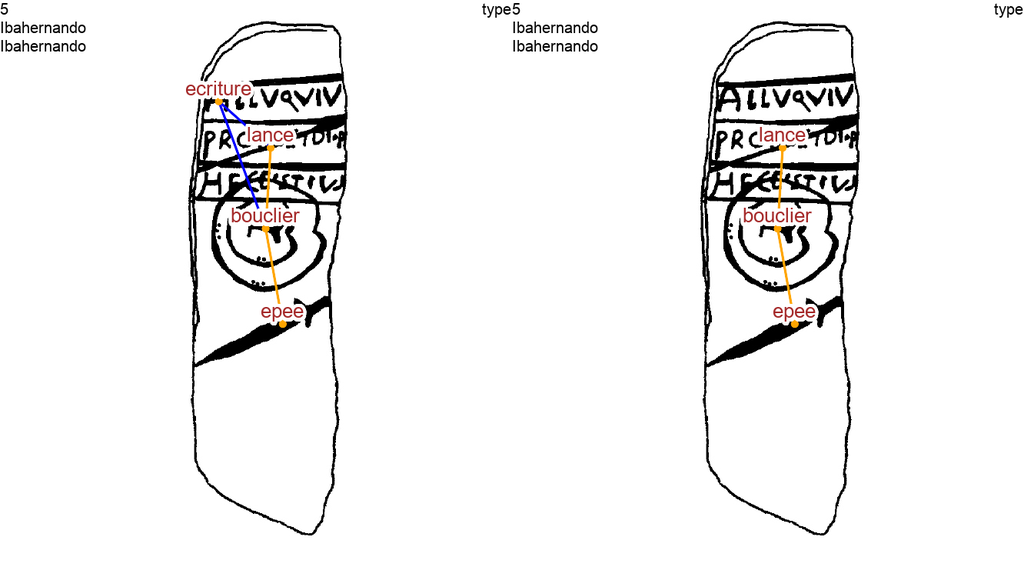

Ibahernando stelae before and after the selection of node 4 (sword) graph component

```r
selected.nd <- 4
nds.df <- read_nds(site = "Ibahernando",
                   decor = "Ibahernando",
                   doss = dataDir)
eds.df <- read_eds(site = "Ibahernando",
                   decor = "Ibahernando",
                   doss = dataDir)
l_dec_df <- contemp_nds(nds.df, eds.df, selected.nd)
Ibahernando <- plot_dec_grph(nodes = nds.df,
                             edges = eds.df,
                             site = "Ibahernando",
                             decor = "Ibahernando",
                             nds.var = "type",
                             lbl.color = "brown",
                             lbl.size=2.2,
                             doss = dataDir)
Ibahernando.img <- magick::image_read(Ibahernando)
Ibahernando.contemp <- plot_dec_grph(nodes = l_dec_df[[1]],
                                     edges = l_dec_df[[2]],
                                     site = "Ibahernando",
                                     decor = "Ibahernando",
                                     nds.var = "type",
                                     lbl.color = "brown",
                                     lbl.size=2.2,
                                     doss = dataDir)
Ibahernando.contemp.img <- magick::image_read(Ibahernando.contemp)
magick::image_append(c(Ibahernando.img, Ibahernando.contemp.img))
```

At the opposite, epigraphist will study only the latin writing

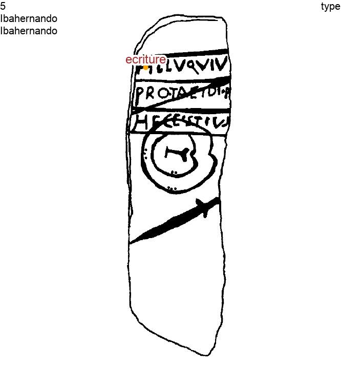

Ibahernando steale after the selection of node 1 (writing) graph component

```r
selected.nd <- 1
nds.df <- read_nds(site = "Ibahernando",
                   decor = "Ibahernando",
                   doss = dataDir)
eds.df <- read_eds(site = "Ibahernando",
                   decor = "Ibahernando",
                   doss = dataDir)
l_dec_df <- contemp_nds(nds.df, eds.df, selected.nd)
img.graph <- plot_dec_grph(nodes = l_dec_df[[1]],
                           edges = l_dec_df[[2]],
                           site = "Ibahernando",
                           decor = "Ibahernando",
                           nds.var = "type",
                           lbl.size = 2,
                           lbl.color = "brown",
                           doss = dataDir)
magick::image_read(img.graph)
```

# Dataset

The training dataset are drawings with their listing and data for nodes, edges. The current path of training dataset is the *exdata/* folder.

```r
# dataDir <- "C:/Documents/decorr/inst/extdata/"
dataDir <- system.file("extdata", package = "decorr")
cat(list.files(dataDir), sep="\n")
> _compar_eds_2_3.png
> _compar_eds_2_4.png
> _compar_eds_3_4.png
> _compar_nds_2_3.png
> _compar_nds_2_4.png
> _compar_nds_3_4.png
> 1_Cerro Muriano_Cerro Muriano 1_long_cm.png
> 1_Cerro Muriano_Cerro Muriano 1_type.png
> 3_Brozas_Brozas_type.png
> 4_Zarza de Montanchez_Zarza De Montanchez_id.png
> 4_Zarza de Montanchez_Zarza De Montanchez_type.png
> 5_Ibahernando_Ibahernando_id.png
> 5_Ibahernando_Ibahernando_type.png
> Brozas.Brozas.jpg
> Cerro_Muriano.Cerro_Muriano_1.jpg
> edges.csv
> edges.dbf
> edges.shp
> edges.shx
> edges.tsv
> gis.png
> Ibahernando.Ibahernando.jpg
> imgs.csv
> imgs.tsv
> nodes.csv
> nodes.dbf
> nodes.shp
> nodes.shx
> nodes.tsv
> Torrejon_Rubio.Torrejon_Rubio_1.jpg
> Zarza_de_Montanchez.Zarza_de_Montanchez.jpg
```

Each decoration is identified by its the name and the name of the site it belongs. Each decoration is a set of:

- a drawing/image (common formats: `jpg, png, jpeg, tiff, pdf,` etc.)
- a dataframe of decoration identifiers (`.tsv` or `.csv`)
- a dataframe of nodes (`.tsv`, `.csv` or `.shp`)
- a dataframe of edges (`.tsv`, `.csv` or `.shp`)

Since a GIS interface is often the most practicale to record nodes and edges, the package has been designed to accept shapefiles (`.shp`) for nodes (`POINTS` geometries) and edges (`LINES` geometries). Tabular data can be `.tsv` (tab-separated values) or `.csv` (semicolons-separated values)

## Drawings/Images

For a given decoration, its drawing (ie, images, raster, grid) is the space of reference of the graph: nodes and edges inherit their coordinates from the decoration grid. Identifiers and paths to images are stored in the `imgs` dataframe

```r
imgs_path <- paste0(dataDir, "/imgs.tsv")
imgs <- read.table(imgs_path, sep="\t", stringsAsFactors = FALSE)
knitr::kable(imgs, "html") %>%
  kable_styling(full_width = FALSE, position = "center", font_size=12)
```

| idf | site | decor | img |
| --- | --- | --- | --- |
| 1 | Cerro Muriano | Cerro Muriano 1 | Cerro_Muriano.Cerro_Muriano_1.jpg |
| 2 | Torrejon Rubio | Torrejon Rubio 1 | Torrejon_Rubio.Torrejon_Rubio_1.jpg |
| 3 | Brozas | Brozas | Brozas.Brozas.jpg |
| 4 | Zarza de Montanchez | Zarza De Montanchez | Zarza_de_Montanchez.Zarza_De_Montanchez.jpg |
| 5 | Ibahernando | Ibahernando | Ibahernando.Ibahernando.jpg |

The decorations unique identifiers are the concatenation of the site name and decoration name. For example, the name of the Cerrano Muriano 1 decoration is `Cerro_Muriano.Cerro_Muriano_1.jpg`.

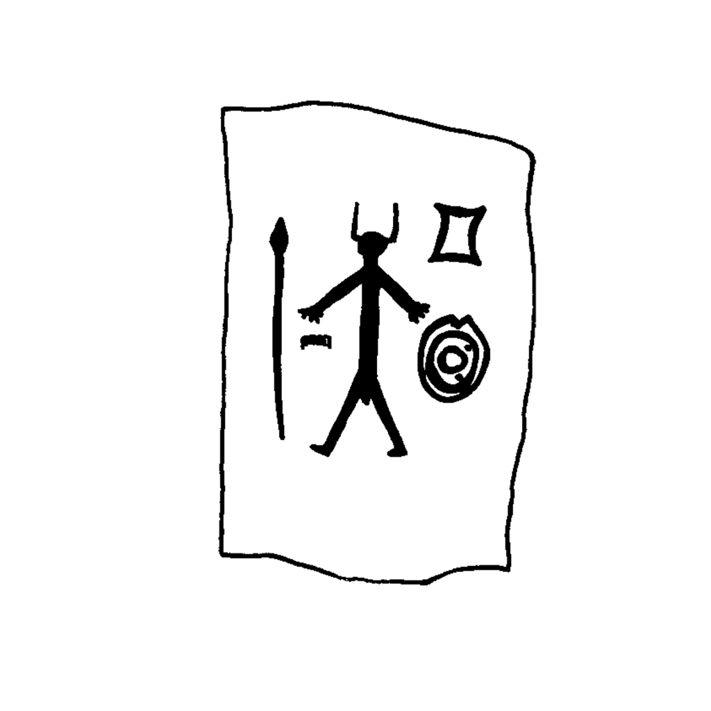

Cerro_Muriano.Cerro_Muriano_1.jpg

```r
library(magick)
plot(image_trim(image_read(paste0(dataDir, "/", imgs[1,"img"]))))
```

This drawing, like all the training dataset drawings, have been published by M. Diaz-Guardamino (Diaz-Guardamino 2010)

## Nodes data

Nodes are stored in a dataframe (`.csv` or `.tsv`) or a shapefile (`.shp`). If the input data comes from a dataframe (`.csv` or `.tsv`), coordinates columns `x` and `y` are required

```r
nds.df <- read_nds(site = "Cerro Muriano", decor = "Cerro Muriano 1", doss = dataDir)
knitr::kable(nds.df, "html") %>%
  kable_styling(full_width = FALSE, position = "center", font_size=12)
```

| site | decor | id | type | x | y |
| --- | --- | --- | --- | --- | --- |
| Cerro Muriano | Cerro Muriano 1 | 1 | personnage | 349.8148 | -298.3244 |
| Cerro Muriano | Cerro Muriano 1 | 2 | casque | 349.8148 | -243.9851 |
| Cerro Muriano | Cerro Muriano 1 | 3 | lance | 238.4637 | -298.3244 |
| Cerro Muriano | Cerro Muriano 1 | 4 | bouclier | 446.0222 | -381.1697 |
| Cerro Muriano | Cerro Muriano 1 | 5 | peigne | 283.0041 | -358.0086 |
| Cerro Muriano | Cerro Muriano 1 | 7 | sexe_masculin | 342.6884 | -427.4917 |
| Cerro Muriano | Cerro Muriano 1 | 8 | lingot_pdb | 451.1489 | -237.4782 |

While, in theory, the nodes are the exacts centroids of each GU, in a more handy manner they can be located manually near to these centroids.

**column names**

- `site`: decoration site
- `decor`: decoration name
- `id`: id of the edges (a unique number)
- `type`: type of the nodes
- `x, y`: coordinates of the nodes

## Edges data

Edges are stored in a dataframe (`.csv` or `.tsv`) or a shapefile (`.shp`).

```r
edges <- read.table(edges_path, sep="\t", stringsAsFactors = FALSE)
knitr::kable(head(edges), "html") %>%
  kable_styling(full_width = FALSE, position = "center", font_size=12) %>%
  gsub("\\+", "$$+$$", .)
```

| site | decor | a | b | type |
| --- | --- | --- | --- | --- |
| Cerro Muriano | Cerro Muriano 1 | 1 | 4 | = |
| Cerro Muriano | Cerro Muriano 1 | 1 | 5 | = |
| Cerro Muriano | Cerro Muriano 1 | 3 | 5 | = |
| Cerro Muriano | Cerro Muriano 1 | 1 | 2 | $$+$$ |
| Cerro Muriano | Cerro Muriano 1 | 1 | 7 | $$+$$ |
| Cerro Muriano | Cerro Muriano 1 | 3 | 1 | = |

Edges geometries are stored as `LINES` between a starting node (columns `xa` and `ya`) and a ending node (columns `xa` and `ya`). They are recalculated from nodes geometries with a join between `id` nodes’ field and the `a` and `b` edges’ fields.

```r
eds.df <- read_eds(site = "Cerro Muriano", decor = "Cerro Muriano 1", doss = dataDir)
knitr::kable(eds.df, "html") %>%
  kable_styling(full_width = FALSE, position = "center", font_size=12) %>%
  gsub("\\+", "$$+$$", .)
```

| site | decor | a | b | type | xa | ya | xb | yb |
| --- | --- | --- | --- | --- | --- | --- | --- | --- |
| Cerro Muriano | Cerro Muriano 1 | 1 | 4 | = | 349.8148 | -298.3244 | 446.0222 | -381.1697 |
| Cerro Muriano | Cerro Muriano 1 | 1 | 5 | = | 349.8148 | -298.3244 | 283.0041 | -358.0086 |
| Cerro Muriano | Cerro Muriano 1 | 3 | 5 | = | 238.4637 | -298.3244 | 283.0041 | -358.0086 |
| Cerro Muriano | Cerro Muriano 1 | 1 | 2 | $$+$$ | 349.8148 | -298.3244 | 349.8148 | -243.9851 |
| Cerro Muriano | Cerro Muriano 1 | 1 | 7 | $$+$$ | 349.8148 | -298.3244 | 342.6884 | -427.4917 |
| Cerro Muriano | Cerro Muriano 1 | 3 | 1 | = | 238.4637 | -298.3244 | 349.8148 | -298.3244 |
| Cerro Muriano | Cerro Muriano 1 | 1 | 8 | = | 349.8148 | -298.3244 | 451.1489 | -237.4782 |
| Cerro Muriano | Cerro Muriano 1 | 4 | 8 | = | 446.0222 | -381.1697 | 451.1489 | -237.4782 |

**column names**

### Edges types

As stated by the graph theory, edges can be undirected or directed. In the `decorr` package, by default:

- all comtemporaneous nodes have *normal* edges or *attribute* edges edges displayed in **orange**
- all non-comtemporaneous nodes have *overlap* edges and displayed in **blue** edges (see contemporaneous nodes).

#### *normal* edges

The *normal* edges are undirected: `1-=-2` is equal to `2-=-1`, node 1 and node 2 are two different *main* nodes. Differents *main* nodes considerated as contemporaneous and close one with another, shared an edge with the value `=` (textual notation: `-=-`) for their `type`. By convention, these edges are called *normal* and displayed with a plain line.

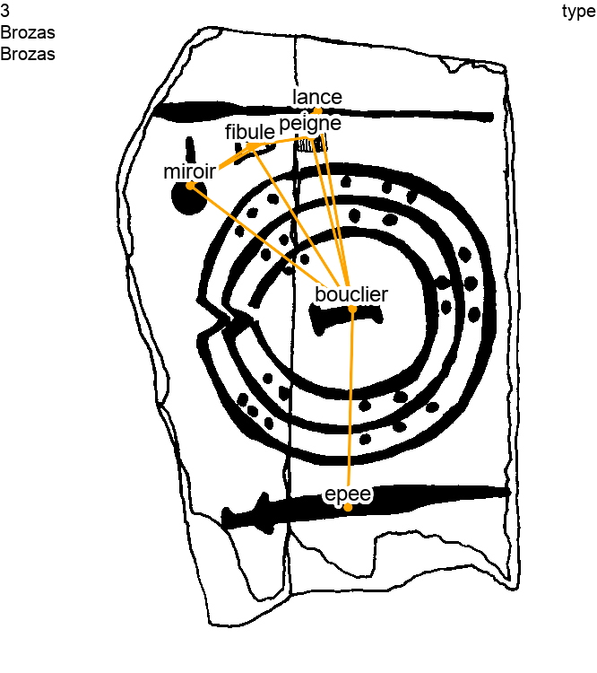

Brozas decoration with only *normal* edges: all the composition seems contemporaneous

```r
nds.df <- read_nds(site = "Brozas",
                   decor = "Brozas",
                   doss = dataDir)
eds.df <- read_eds(site = "Brozas",
                   decor = "Brozas",
                   doss = dataDir)
img.graph <- plot_dec_grph(nodes = nds.df,
                           edges = eds.df,
                           site = "Brozas",
                           decor = "Brozas",
                           nds.var= 'type',
                           lbl.size = 2,
                           doss = dataDir)
magick::image_read(img.graph)
```

For example, the *normal* edge between the nodes `5` and `6` (respectively the shield and a sword) is:

```r
eds.df <- read_eds(site = "Brozas", decor = "Brozas", doss = dataDir)
cat(paste0(eds.df[10,"a"],"-",eds.df[10,"type"],"-",eds.df[10,"b"]))
> 5-=-6
```

#### *attribute* edges

When a node is an attribute of another, edges are identified with a `+` (textual notation: `-+-`) and displayed with a dashed line. The *attribute* edges are directed: `1-+-2` is not equal to `2-+-1`, `1-+-2` means that node 1 is the *main* node and node 2 is one of its *attribute* node. For example, at the bottom of the `Zarza De Montanchez` decoration, the main node chariot `7` is connected with four nodes attributes:

- two horses (cheval): `8` and `9`
- two wheels (roue): `10` and `11`

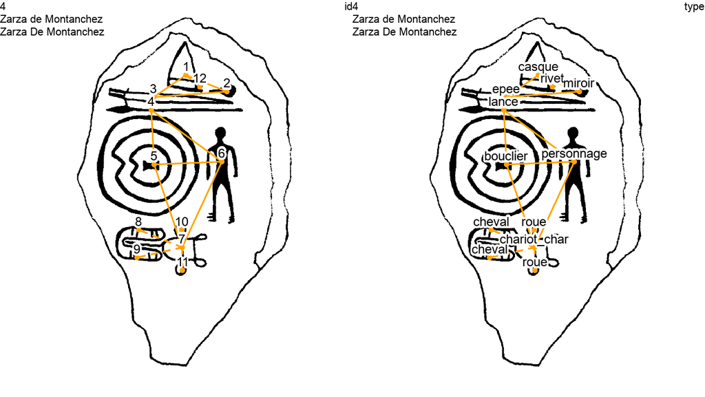

Zarza De Montanchez decoration showing *normal* and *attribute* edges

```r
nds.df <- read_nds(site = "Zarza de Montanchez",
                   decor = "Zarza De Montanchez",
                   doss = dataDir)
eds.df <- read_eds(site = "Zarza de Montanchez",
                   decor = "Zarza De Montanchez",
                   doss = dataDir)
img.graph.id <- plot_dec_grph(nodes = nds.df,
                              edges = eds.df,
                              site = "Zarza de Montanchez",
                              decor = "Zarza De Montanchez",
                              lbl.size = 2,
                              doss = dataDir)
img.graph.type <- plot_dec_grph(nodes = nds.df,
                                edges = eds.df,
                                site = "Zarza de Montanchez",
                                decor = "Zarza De Montanchez",
                                lbl.size = 2,
                                nds.var = 'type',
                                doss = dataDir)
magick::image_append(c(magick::image_read(img.graph.id),
                       magick::image_read(img.graph.type)))
```

For example, the attribute edge between the nodes `7` and `8` (respectively the chariot and a horse) is:

```r
eds.df <- read_eds(site = "Zarza de Montanchez", decor = "Zarza De Montanchez", doss = dataDir)
cat(paste0(eds.df[8,"a"],"-",eds.df[8,"type"],"-",eds.df[8,"b"]))
> 7-+-8
```

#### *overlap* edges

When a node overlaps another – or is more recent than another – edges are identified with a `>` (textual notation: `->-`) and displayed with a blue plain line. The *overlap* edges are directed: `1->-2` is not equal to `2->-1`, `1->-2` means that node 1 overlaps node 2. For example, the Ibahernando stelae shows a latin writing (écriture) overlapping a spear (lance) and a shield (bouclier).

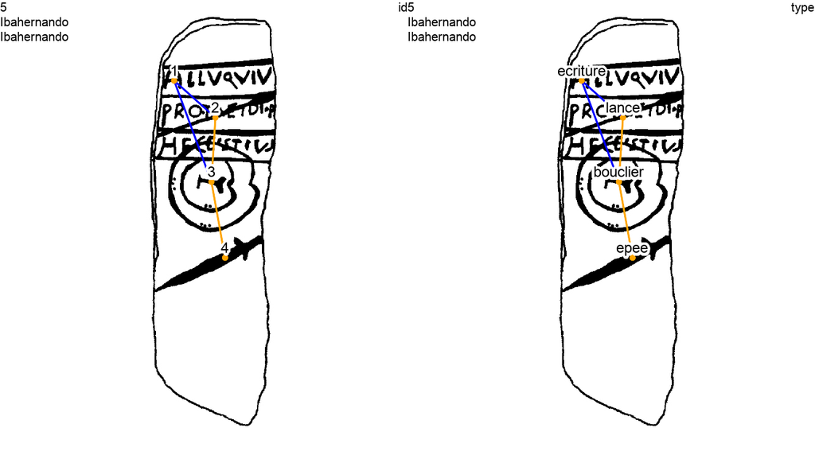

Ibahernando decoration showing *normal* and *overlap* edges

```r
nds.df <- read_nds(site = "Ibahernando",
                   decor = "Ibahernando",
                   doss = dataDir)
eds.df <- read_eds(site = "Ibahernando",
                   decor = "Ibahernando",
                   doss = dataDir)
img.graph.id <- plot_dec_grph(nodes = nds.df,
                           edges = eds.df,
                           site = "Ibahernando",
                           decor = "Ibahernando",
                           lbl.size = 2,
                           doss = dataDir)
img.graph.type <- plot_dec_grph(nodes = nds.df,
                           edges = eds.df,
                           site = "Ibahernando",
                           decor = "Ibahernando",
                           nds.var = 'type',
                           lbl.size = 2,
                           doss = dataDir)
magick::image_append(c(magick::image_read(img.graph.id),
                       magick::image_read(img.graph.type)))
```

For example, the *overlap* edge between the nodes 1 and 2 (respectively the writing and the spear) is:

```r
eds.df <- read_eds(site = "Ibahernando", decor = "Ibahernando", doss = dataDir)
cat(paste0(eds.df[1,"a"],"-",eds.df[1,"type"],"-",eds.df[1,"b"]))
> 1->-2
```

To remove one of the two connected component of the Ibahernando stelae, see the section **Manage contemporaneous contents**

# References

Alexander, Craig. 2008. “The Bedolina Map – an Exploratory Network Analysis.” *Layers of Perception. Proceedings of the 35th International Conference on Computer Applications and Quantitative Methods in Archaeology (CAA), Berlin, 2.-6. April 2007*, 366–71. https://archiv.ub.uni-heidelberg.de/propylaeumdok/512/1/11_04_alexander_bedolina.pdf.

Bash, Martin Almagro. 1966. *Las Estelas Decoradas Del Suroeste Peninsular*. *Editorial CSIC-CSIC Press*.

Diaz-Guardamino, Marta. 2010. “Las Estelas Decoradas En La Prehistoria de La Peninsula Iberica.” https://eprints.ucm.es/11070/1/T32200.pdf.

Huet, Thomas. 2018. “Geometric Graphs to Study Ceramic Decoration.” *Proceedings of the 44th Conference on Computer Applications and Quantitative Methods in Archaeology, CAA 2016*, 311–24. https://www.researchgate.net/publication/343514122_Geometric_graphs_to_study_ceramic_decoration.

Huet, Thomas, and Craig Alexander. 2015. “Méthodes Informatiques Pour L’étude Des Gravures Rupestres : Les Exemples Du Valcamonica (Italie) et Du Mont Bego (France).” *Recherches Sur L’âge Du Bronze, Nouvelles Approches et Perspectives, Actes de La Journée d’étude de L’Association Pour La Promotion Des Recherches Archéologiques Sur L’âge Du Bronze, 28 Février 2014, Saint-Germain-En-Laye*, 15–29. https://www.academia.edu/38252719/M%C3%A9thodes_informatiques_pour_l_%C3%A9tude_des_gravures_rupestres_les_exemples_du_Valcamonica_Italie_et_du_mont_Bego_France_.

Toussaint, G. T. 1980. “The Relative Neighbourhood Graph of a Finite Planar Set.” *Pattern Recognition* 12 (4): 261–68. http://citeseerx.ist.psu.edu/viewdoc/download?doi=10.1.1.54.6448&rep=rep1&type=pdf.